# PUBLPOL 218X Assignment 2

Tiffany Zhu

November 04, 2020

# 1 Educational attainment by race

## 1.1 Data setup

```r
acs_vars_2018_5yr <-
  listCensusMetadata(
    name = "2018/acs/acs5",
    type = "variables"
  )
acs_vars_2019_1yr <-
  listCensusMetadata(
    name = "2019/acs/acs1",
    type = "variables"
  )

census_race_labels = c("White Alone",
                       "Black or African American",
                       "American Indian and Alaska Native Alone",
                       "Asian Alone",
                       "Native Hawaiian and Other Pacific Islander Alone)",
                       "Some Other Race Alone",
                       "Two or More Races")
bay_educ_race = 1:7 %>%
  map_dfr(function(x) {
    getCensus(name = "acs/acs1",
              vintage = 2019,
              region = "county:085",
              regionin = "state:06",
              vars = paste0("group(B15002", LETTERS[x], ")")) %>%
    select(!c(GEO_ID, state, NAME) &
           !ends_with(c("EA", "MA", "M"))) %>%
    pivot_longer(ends_with("E"),
                 names_to = "variable",
                 values_to = "estimate") %>%
    left_join(acs_vars_2019_1yr %>% select(name, label),
                                    by = c("variable" = "name")) %>%
    select(-variable) %>%
    separate(label,
             into = c(NA, NA, "sex", "education"),
             sep = "!!") %>%
    filter(!is.na(education)) %>%
    mutate(race = census_race_labels[x])
    })
bay_educ_race
```

```
## # A tibble: 112 x 5
##    county estimate sex     education                       race
##    <chr>     <dbl> <chr>   <chr>                           <chr>
##  1 085       16211 Male:   Less than 9th grade             White Alone
##  2 085       14016 Male:   9th to 12th grade, no diploma   White Alone
##  3 085       41254 Male:   Regular high school diploma     White Alone
##  4 085        6148 Male:   GED or alternative credential   White Alone
##  5 085       51787 Male:   Some college, no degree         White Alone
##  6 085       18498 Male:   Associate's degree              White Alone
##  7 085       89757 Male:   Bachelor's degree               White Alone
##  8 085       80498 Male:   Graduate or professional degree White Alone
##  9 085       16758 Female: Less than 9th grade             White Alone
## 10 085       11593 Female: 9th to 12th grade, no diploma   White Alone
## # … with 102 more rows
```

## 1.2 Graphing educational attainment by race

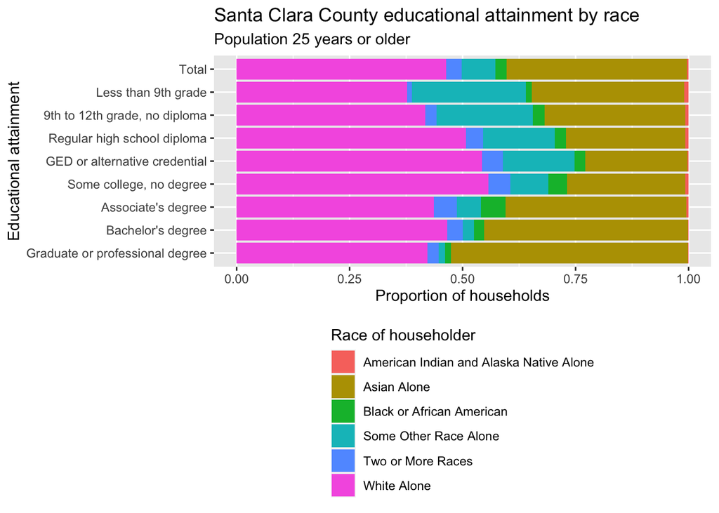

```r
bay_race_total = bay_educ_race %>%
                 group_by(race) %>%
                 summarize(estimate = sum(estimate)) %>%
                 mutate(education = "Total")
bay_educ_race %>% group_by(education, race) %>%
                  summarize(estimate = sum(estimate)) %>%
                  rbind(bay_race_total) %>%
                  ggplot() +
                  geom_bar(aes(x = education %>%
                                   factor(levels = rev(c("Total",
                                                         bay_educ_race$education[1:8]))),
                               y = estimate,
                               fill = race),
                           stat = "identity",
                           position = "fill") +
                  labs(x = "Educational attainment",
                       y = "Proportion of households",
                       title = "Santa Clara County educational attainment by race",
                       subtitle = "Population 25 years or older",
                       fill = "Race of householder") +
                  coord_flip() +
                  theme(legend.position = "bottom",
                        legend.direction = "vertical")
```

## 1.3 Analysis

- “Some Other Race Alone” (unspecified by definition, but I am guessing these are primarily Hispanics/Latinos) is disproportionately represented among lower educational attainment levels (GED/high school diploma or less).
- Asians are overrepresented among those with bachelor’s and graduate/professional degrees.
- Interestingly enough, white people are overrepresented among those with high school diplomas, GEDs or alternative credentials, and those with some college and no degree.

We can observe some more interesting phenomena by flipping our analysis, that is, looking at the composition of educational attainment for every race.

## 1.4 Flipping the axes: Race by educational attainment

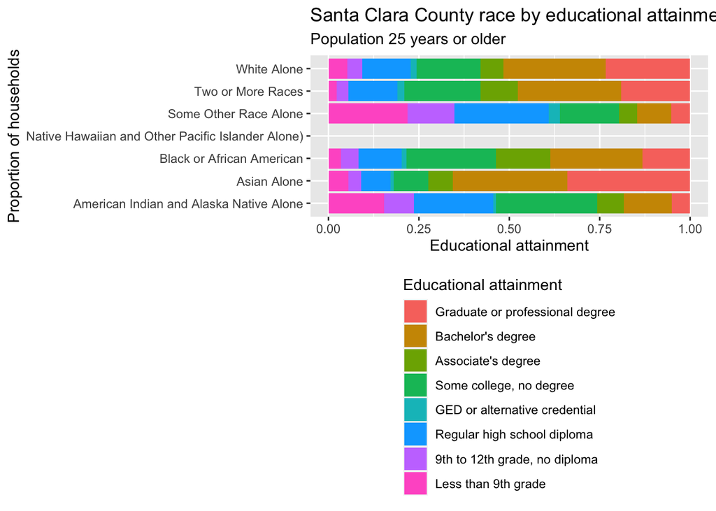

```r
bay_educ_race %>% group_by(education, race) %>%
                  summarize(estimate = sum(estimate)) %>%
                  ggplot() +
                  geom_bar(aes(x = race,
                               y = estimate,
                               fill = education %>%
                                      factor(levels = rev(c("Total",
                                                            bay_educ_race$education[1:8])))),
                           stat = "identity",
                           position = "fill") +
                  labs(x = "Proportion of households",
                       y = "Educational attainment",
                       title = "Santa Clara County race by educational attainment",
                       subtitle = "Population 25 years or older",
                       fill = "Educational attainment") +
                  coord_flip() +
                  theme(legend.position = "bottom",
                        legend.direction = "vertical")
```

## 1.5 Analysis

- There seems to be insufficient data among Native Hawaiian and Pacific Islander populations to plot their data.
- Over half of Asians and whites hold a bachelor’s degree or higher.
- On the other hand, between 25% and 50% of Blacks and less than 25% of American Indians and Alaska Natives and those of “Some Other Race Alone”.

# 2 Number and percentage of K-12 students without Internet access

## 2.1 Data setup

```r
ca_pums = get_pums(variables = c("PUMA", "ACCESS", "SCHG"),
                   state = "CA",
                   year = 2018,
                   survey = "acs5",
                   recode = T)
saveRDS(ca_pums, file = "ca_pums.rds")
```

```r
pums_vars_2018 = pums_variables %>%
                 filter(year == 2018, survey == "acs5")
pums_vars_2018_inds = pums_vars_2018 %>%
                      distinct(var_code, var_label, data_type, level) %>%
                      filter(level == "person")
ca_pums = readRDS("ca_pums.rds")
ca_pumas = pumas("CA", cb = T, progress_bar = F)

# Isolate Santa Clara County
ca_counties = counties("CA", cb = T, progress_bar = F)
county_name = c("Santa Clara")
sc_county = ca_counties %>%
            filter(NAME %in% county_name)

sc_pumas = ca_pumas %>%
           st_centroid() %>%
           .[sc_county, ] %>%
           mutate(PUMACE10 = as.numeric(PUMACE10)) %>%
           st_set_geometry(NULL) %>%
           left_join(ca_pumas %>% select(GEOID10)) %>%
           st_as_sf()
sc_pums = ca_pums  %>%
          mutate(PUMA = as.numeric(PUMA)) %>%
          filter(PUMA %in% sc_pumas$PUMACE10)
```

```r
# Generate number of K-12 students without internet
sc_internet = sc_pums %>%
              filter(!duplicated(SERIALNO)) %>%
              mutate(ACCESS = as.numeric(ACCESS),
                     SCHG = as.numeric(SCHG),
                     no_internet = ifelse(
                      (ACCESS == 3) &
                      (SCHG >= 2 &
                       SCHG <= 14),
                      PWGTP,
                      0)) %>%
              group_by(PUMA) %>%
              left_join(sc_pumas %>% select(PUMACE10),
                                     by = c("PUMA" = "PUMACE10"))
# Print number
sum(sc_internet$no_internet, na.rm = T)
```

```
## [1] 35
```

```r
# Total children being tracked
sc_internet %>% filter(SCHG >= 2 & SCHG <= 14) %>% pull(PWGTP) %>% sum()
```

```
## [1] 1835
```

```r
# Percentage of children
sum(sc_internet$no_internet, na.rm = T) /
  (sc_internet %>% filter(SCHG >= 2 & SCHG <= 14) %>% pull(PWGTP) %>% sum())
```

```
## [1] 0.01907357
```

According to the ACS 2018 5-year results, 1.9% of K-12 students in Santa Clara County (35 out of 1835) do not have Internet access. There are a few important caveats to note about the data.

First, in the ACS 2018 and 2019 1-year results, when I ran this same code I ended up with 0 students without Internet access, which I highly doubt is the case — it’s more likely that I got that result because the 1-year samples only draw from highly populated areas, and in Santa Clara County the people least likely to have internet access will likely live in sparsely populated areas not covered by the 1-year sample. This issue suggests that less populated areas that are less likely to have internet access are also less likely to be sampled, and thus that this percentage is probably an underestimate.

A related problem is that the sample of K-12 children is very tiny to begin with. Estimates made from small samples are bound to have a large margin of error: another reason to take this estimate with a grain of salt.

Finally, the 2018 5-year data might not be very useful for understanding the state of internet access in 2020. The 2018 5-year data by definition draws on a sample from 2013-18, and internet access has broadened greatly even just between 2018 and 2020, let alone from 2013 to 2020.

## 2.2 Mapping internet access across the Bay Area

### 2.2.1 Data setup

```r
# Broaden PUMS data to all Bay Area
bay_county_names <-
  c(
    "Alameda",
    "Contra Costa",
    "Marin",
    "Napa",
    "San Francisco",
    "San Mateo",
    "Santa Clara",
    "Solano",
    "Sonoma"
  )
bay_counties = ca_counties %>%
               filter(NAME %in% bay_county_names)
bay_pumas = ca_pumas %>%
            st_centroid() %>%
            .[bay_counties, ] %>%
            mutate(PUMACE10 = as.numeric(PUMACE10)) %>%
            st_set_geometry(NULL) %>%
            left_join(ca_pumas %>% select(GEOID10)) %>%
            st_as_sf()
bay_pums = ca_pums  %>%
           mutate(PUMA = as.numeric(PUMA)) %>%
           filter(PUMA %in% bay_pumas$PUMACE10)

# Generate number of K-12 students without internet
bay_internet = bay_pums %>%
               filter(!duplicated(SERIALNO)) %>%
               mutate(ACCESS = as.numeric(ACCESS),
                      SCHG = as.numeric(SCHG),
                      no_internet = ifelse(
                       (ACCESS == 3) &
                       (SCHG >= 2 &
                        SCHG <= 14),
                       PWGTP,
                       0)) %>%
               filter(SCHG >= 2 & SCHG <= 14) %>%
               group_by(PUMA) %>%
               summarize(perc_nointernet = sum(no_internet, na.rm = T)/
                                           (sum(PWGTP, na.rm = T))) %>%
               left_join(bay_pumas %>% select(PUMACE10),
                                       by = c("PUMA" = "PUMACE10")) %>%
               st_as_sf()
```

### 2.2.2 Map

```r
pums_pal = colorNumeric(palette = "Oranges",
                        domain = bay_internet$perc_nointernet)

leaflet() %>%
  addTiles() %>%
  addPolygons(data = bay_internet,
              fillColor = ~pums_pal(perc_nointernet),
              color = "white",
              opacity = 0.5,
              fillOpacity = 0.5,
              weight = 1,
              label = ~paste0(perc_nointernet,
                              "% K-12 students without Internet access"),
              highlightOptions = highlightOptions(weight = 2, opacity = 1)) %>%
  addLegend(data = bay_internet,
            pal = pums_pal,
            values = ~perc_nointernet,
            title = "% K-12 students<br>without Internet access")
```

[interactive chart not shown]

# 3 Migration by education

## 3.1 Data setup

```r
acs_vars_2019_1yr = listCensusMetadata(name = "2019/acs/acs1", type = "variables")

sc_mobility_current_19 = getCensus(name = "acs/acs1",
                                   vintage = 2019,
                                   region = "county:085",
                                   regionin = "state:06",
                                   vars = c("group(B07009)")) %>%
                          select(!c(GEO_ID, state, NAME) &
                                 !ends_with(c("EA", "MA", "M"))) %>%
                          pivot_longer(ends_with("E"),
                                       names_to = "variable",
                                       values_to = "estimate") %>%
                          left_join(acs_vars_2019_1yr %>% select(name, label),
                                    by = c("variable" = "name")) %>%
                          select(-variable) %>%
                          separate(label,
                                   into = c(NA, NA, "mobility", "education"),
                                   sep = "!!") %>%
                          mutate(mobility = ifelse(mobility %in% c("Same house 1 year ago:", "Moved within same country"),
                                   "Here since last year",
                                   "Inflow")) %>%
                          filter(!is.na(education)) %>%
                          group_by(mobility, education) %>%
                          summarize(estimate = sum(estimate))
smc_mobility_lastyear_19 = getCensus(name = "acs/acs1",
                                    vintage = 2019,
                                    region = "county:085",
                                    regionin = "state:06",
                                    vars = c("group(B07409)")) %>%
                           select(!c(GEO_ID, state, NAME) &
                                 !ends_with(c("EA", "MA", "M"))) %>%
                           pivot_longer(ends_with("E"),
                                       names_to = "variable",
                                       values_to = "estimate") %>%
                           left_join(acs_vars_2019_1yr %>% select(name, label),
                                    by = c("variable" = "name")) %>%
                           select(-variable) %>%
                           separate(label,
                                    into = c(NA, NA, "mobility", "education"),
                                    sep = "!!") %>%
                           mutate(mobility = ifelse(mobility %in% c("Same house:", "Moved within same county:"),
                                                    "Here since last year",
                                                    "Outflow")) %>%
                           filter(!is.na(education)) %>%
                           group_by(mobility, education) %>%
                           summarize(estimate = sum(estimate))
sc_mobility_current_18 = getCensus(name = "acs/acs1",
                                    vintage = 2018,
                                    region = "county:085",
                                    regionin = "state:06",
                                    vars = c("group(B07009)")) %>%
                          select(!c(GEO_ID, state, NAME) &
                                 !ends_with(c("EA", "MA", "M"))) %>%
                          pivot_longer(ends_with("E"),
                                       names_to = "variable",
                                       values_to = "estimate") %>%
                          left_join(acs_vars_2019_1yr %>% select(name, label),
                                    by = c("variable" = "name")) %>%
                          select(-variable) %>%
                          separate(label,
                                   into = c(NA, NA, "mobility", "education"),
                                   sep = "!!") %>%
                          mutate(mobility = "Here last year") %>%
                          filter(!is.na(education)) %>%
                          group_by(mobility, education) %>%
                          summarize(estimate = sum(estimate))
```